# Final Project

STAT 230 Spring 2025

Author

Rozallyn Nahomove, Najada Stroka

# Group members

What are your group members (up to 3 people)?

“Rozallyn Nahomove, Najada Stroka”

# Data

What data set are you using? Emergency Department Visits Related To Mental Health Conditions - This indicator shows the rate of emergency department visits related to mental health disorders (per 100,000 population). Mental health problems can place a heavy burden on the healthcare system, particularly when persons in crisis utilize emergency departments instead of other sources of care when available. In Maryland, there were 207,650 mental health disorder-related emergency department visits in 2014.Diagnoses include adjustment disorders, anxiety disorders, attention deficit disorders, disruptive behavior disorders, mood disorders, personality disorders, schizophrenia, and other psychotic disorders, suicide and intentional self-inflicted injury and miscellaneous mental disorders.

Read data in:

```r
library(tidyverse)
ERvisits<-read_csv("data/SHIP_Emergency_Department_Visits_Related_To_Mental_Health_Conditions_2008-2017.csv")
```

# Questions

What questions are you going to answer with this data set?

# Plots

Distribution of one numeric variable: plot a histogram of one numeric variable Since 2008 has mental health worsen with the amount of ER visits? Does race and enthincity have a big impact on the number of ER visits?

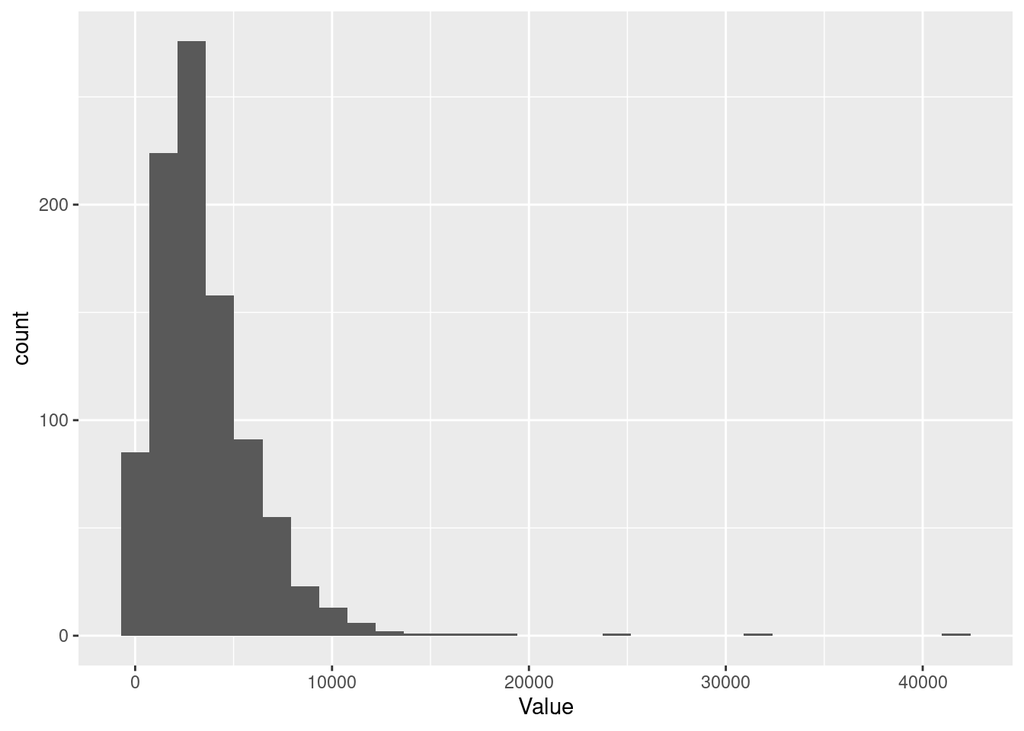

```r
ERvisits|>
  ggplot(aes(x=Value))+
  geom_histogram()
```

Box plot of one numeric variable by one categorical variable: create a box plot of one numeric variable vs. one categorical variable

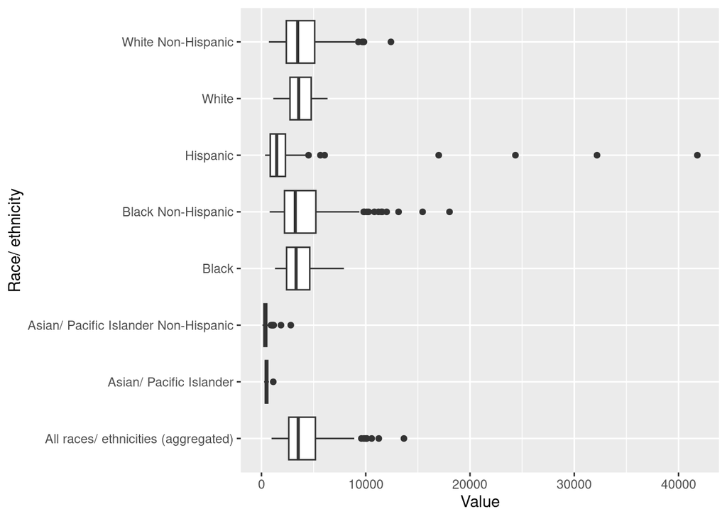

```r
ERvisits|>
  ggplot(aes(x=Value,y=`Race/ ethnicity`))+
  geom_boxplot()
```

Inferential Statistics

```r
Model<-lm(Value~`Race/ ethnicity`,data=ERvisits)
summary(Model)
```

```
Call:
lm(formula = Value ~ `Race/ ethnicity`, data = ERvisits)

Residuals:
   Min     1Q Median     3Q    Max
 -3311  -1529   -480    750  39255

Coefficients:
                                                       Estimate Std. Error
(Intercept)                                            4094.848    177.581
`Race/ ethnicity`Asian/ Pacific Islander              -3551.505   1076.004
`Race/ ethnicity`Asian/ Pacific Islander Non-Hispanic -3614.589    384.021
`Race/ ethnicity`Black                                 -354.698    600.020
`Race/ ethnicity`Black Non-Hispanic                       3.761    260.833
`Race/ ethnicity`Hispanic                             -1547.212    307.579
`Race/ ethnicity`White                                 -482.048    588.969
`Race/ ethnicity`White Non-Hispanic                    -149.379    258.019
                                                      t value Pr(>|t|)
(Intercept)                                            23.059  < 2e-16 ***
`Race/ ethnicity`Asian/ Pacific Islander               -3.301    0.001 **
`Race/ ethnicity`Asian/ Pacific Islander Non-Hispanic  -9.412  < 2e-16 ***
`Race/ ethnicity`Black                                 -0.591    0.555
`Race/ ethnicity`Black Non-Hispanic                     0.014    0.988
`Race/ ethnicity`Hispanic                              -5.030 5.87e-07 ***
`Race/ ethnicity`White                                 -0.818    0.413
`Race/ ethnicity`White Non-Hispanic                    -0.579    0.563
---
Signif. codes:  0 '***' 0.001 '**' 0.01 '*' 0.05 '.' 0.1 ' ' 1

Residual standard error: 2808 on 932 degrees of freedom
  (310 observations deleted due to missingness)
Multiple R-squared:  0.1203,    Adjusted R-squared:  0.1137
F-statistic: 18.21 on 7 and 932 DF,  p-value: < 2.2e-16
```

This project analyzed emergency department visits related to mental health conditions in Maryland from 2008 to 2017. In 2014 alone, there were over 207,000 such visits, with common diagnoses including mood and anxiety disorders, as well as more severe conditions like schizophrenia and other psychotic disorders.